# Ford GoBike Dataset - 2019

## Introduction

> This Ford GoBike dataset includes information about individual riders made in a bike-sharing system covering the greater San Francisco Bay area.

```python
# import all packages and set plots to be embedded inline
import numpy as np
import pandas as pd
import matplotlib.pyplot as plt
import seaborn as sb

%matplotlib inline
```

> Loading and exploring the dataset

```python
df = pd.read_csv('fordgobike-tripdata.csv')
```

```python
#displaying the firts five column of the dataset
df.head()
```

|  | duration_sec | start_time | end_time | start_station_id | start_station_name | start_station_latitude | start_station_longitude | end_station_id | end_station_name | end_station_latitude | end_station_longitude | bike_id | user_type | member_birth_year | member_gender | bike_share_for_all_trip |
| --- | --- | --- | --- | --- | --- | --- | --- | --- | --- | --- | --- | --- | --- | --- | --- | --- |
| 0 | 52185 | 2019-02-28 17:32:10.1450 | 2019-03-01 08:01:55.9750 | 21.0 | Montgomery St BART Station (Market St at 2nd St) | 37.789625 | -122.400811 | 13.0 | Commercial St at Montgomery St | 37.794231 | -122.402923 | 4902 | Customer | 1984.0 | Male | No |
| 1 | 42521 | 2019-02-28 18:53:21.7890 | 2019-03-01 06:42:03.0560 | 23.0 | The Embarcadero at Steuart St | 37.791464 | -122.391034 | 81.0 | Berry St at 4th St | 37.775880 | -122.393170 | 2535 | Customer | NaN | NaN | No |
| 2 | 61854 | 2019-02-28 12:13:13.2180 | 2019-03-01 05:24:08.1460 | 86.0 | Market St at Dolores St | 37.769305 | -122.426826 | 3.0 | Powell St BART Station (Market St at 4th St) | 37.786375 | -122.404904 | 5905 | Customer | 1972.0 | Male | No |
| 3 | 36490 | 2019-02-28 17:54:26.0100 | 2019-03-01 04:02:36.8420 | 375.0 | Grove St at Masonic Ave | 37.774836 | -122.446546 | 70.0 | Central Ave at Fell St | 37.773311 | -122.444293 | 6638 | Subscriber | 1989.0 | Other | No |
| 4 | 1585 | 2019-02-28 23:54:18.5490 | 2019-03-01 00:20:44.0740 | 7.0 | Frank H Ogawa Plaza | 37.804562 | -122.271738 | 222.0 | 10th Ave at E 15th St | 37.792714 | -122.248780 | 4898 | Subscriber | 1974.0 | Male | Yes |

```python
# displaying 5 random samples from the datasets
df.sample(5)
```

|  | duration_sec | start_time | end_time | start_station_id | start_station_name | start_station_latitude | start_station_longitude | end_station_id | end_station_name | end_station_latitude | end_station_longitude | bike_id | user_type | member_birth_year | member_gender | bike_share_for_all_trip |
| --- | --- | --- | --- | --- | --- | --- | --- | --- | --- | --- | --- | --- | --- | --- | --- | --- |
| 147620 | 263 | 2019-02-07 07:38:06.9790 | 2019-02-07 07:42:30.4360 | 58.0 | Market St at 10th St | 37.776619 | -122.417385 | 88.0 | 11th St at Bryant St | 37.770030 | -122.411726 | 4951 | Subscriber | 1987.0 | Male | No |
| 72218 | 376 | 2019-02-19 16:46:49.7390 | 2019-02-19 16:53:06.2140 | 350.0 | 8th St at Brannan St | 37.771431 | -122.405787 | 44.0 | Civic Center/UN Plaza BART Station (Market St ... | 37.781074 | -122.411738 | 5958 | Subscriber | 1977.0 | Male | No |
| 107898 | 109 | 2019-02-13 13:06:54.4990 | 2019-02-13 13:08:44.3980 | 243.0 | Bancroft Way at College Ave | 37.869360 | -122.254337 | 239.0 | Bancroft Way at Telegraph Ave | 37.868813 | -122.258764 | 1739 | Subscriber | 1992.0 | Male | No |
| 38550 | 474 | 2019-02-23 11:45:16.6950 | 2019-02-23 11:53:11.1850 | 66.0 | 3rd St at Townsend St | 37.778742 | -122.392741 | 3.0 | Powell St BART Station (Market St at 4th St) | 37.786375 | -122.404904 | 2053 | Subscriber | 1986.0 | Male | No |
| 26149 | 180 | 2019-02-25 13:36:46.8870 | 2019-02-25 13:39:47.8180 | 8.0 | The Embarcadero at Vallejo St | 37.799953 | -122.398525 | 16.0 | Steuart St at Market St | 37.794130 | -122.394430 | 5958 | Subscriber | 1974.0 | Female | No |

```python
# exploring high-level overview of data shape and composition
print(df.shape)
print(df.dtypes)
```

```
(183412, 16)
duration_sec                 int64
start_time                  object
end_time                    object
start_station_id           float64
start_station_name          object
start_station_latitude     float64
start_station_longitude    float64
end_station_id             float64
end_station_name            object
end_station_latitude       float64
end_station_longitude      float64
bike_id                      int64
user_type                   object
member_birth_year          float64
member_gender               object
bike_share_for_all_trip     object
dtype: object
```

```python
# descriptive statistics for numeric variables
df.describe()
```

|  | duration_sec | start_station_id | start_station_latitude | start_station_longitude | end_station_id | end_station_latitude | end_station_longitude | bike_id | member_birth_year |
| --- | --- | --- | --- | --- | --- | --- | --- | --- | --- |
| count | 183412.000000 | 183215.000000 | 183412.000000 | 183412.000000 | 183215.000000 | 183412.000000 | 183412.000000 | 183412.000000 | 175147.000000 |
| mean | 726.078435 | 138.590427 | 37.771223 | -122.352664 | 136.249123 | 37.771427 | -122.352250 | 4472.906375 | 1984.806437 |
| std | 1794.389780 | 111.778864 | 0.099581 | 0.117097 | 111.515131 | 0.099490 | 0.116673 | 1664.383394 | 10.116689 |
| min | 61.000000 | 3.000000 | 37.317298 | -122.453704 | 3.000000 | 37.317298 | -122.453704 | 11.000000 | 1878.000000 |
| 25% | 325.000000 | 47.000000 | 37.770083 | -122.412408 | 44.000000 | 37.770407 | -122.411726 | 3777.000000 | 1980.000000 |
| 50% | 514.000000 | 104.000000 | 37.780760 | -122.398285 | 100.000000 | 37.781010 | -122.398279 | 4958.000000 | 1987.000000 |
| 75% | 796.000000 | 239.000000 | 37.797280 | -122.286533 | 235.000000 | 37.797320 | -122.288045 | 5502.000000 | 1992.000000 |
| max | 85444.000000 | 398.000000 | 37.880222 | -121.874119 | 398.000000 | 37.880222 | -121.874119 | 6645.000000 | 2001.000000 |

```python
# checking the data basic information
df.info()
```

```
<class 'pandas.core.frame.DataFrame'>
RangeIndex: 183412 entries, 0 to 183411
Data columns (total 16 columns):
duration_sec               183412 non-null int64
start_time                 183412 non-null object
end_time                   183412 non-null object
start_station_id           183215 non-null float64
start_station_name         183215 non-null object
start_station_latitude     183412 non-null float64
start_station_longitude    183412 non-null float64
end_station_id             183215 non-null float64
end_station_name           183215 non-null object
end_station_latitude       183412 non-null float64
end_station_longitude      183412 non-null float64
bike_id                    183412 non-null int64
user_type                  183412 non-null object
member_birth_year          175147 non-null float64
member_gender              175147 non-null object
bike_share_for_all_trip    183412 non-null object
dtypes: float64(7), int64(2), object(7)
memory usage: 22.4+ MB
```

```python
# Checking for duplicated data (The data does not have anyduplicated value)
df.duplicated().sum()
```

```
0
```

### Cleaning

> There are several quality problems that need to be resolved before analyzing and visualizing the data.
> 1. member_birth_year should be converted to interger format from the float format
> 2. user_type, member_gender, bike_share_for_all_trip should all be in categorical format
> 3. start_time and end_time should be converted to date_time format
> 4. create a colum for each riders actual age and convert to integer format
> 5. Add riders start month and days and end month and days and to the column using start time
> 6. Add Total distance traveled column by using latitude and longitude

```python
# create a copy of the dataset to be cleaned
df_clean = df.copy()
```

#### DEFINE

Converting highlighted columns into the required datatypes

#### CODE

```python
#changing member_birth_year column from float to interger
df_clean.member_birth_year = df_clean.member_birth_year.astype(int)
```

```python
# Changing the user_type, member_gender, and bike_share_for_all_trip to category format
df_clean.user_type = df_clean.user_type.astype('category')
df_clean.member_gender = df_clean.member_gender.astype('category')
df_clean.bike_share_for_all_trip = df_clean.bike_share_for_all_trip.astype('category')
```

```python
# Changing start_time and end_time column from object to date_time
df_clean.start_time = pd.to_datetime(df_clean.start_time)
df_clean.end_time = pd.to_datetime(df_clean.end_time)
```

```python
#Creating a new column for the riders age
df_clean['member_age'] = 2019 - df_clean['member_birth_year']
df_clean.member_age = df_clean.member_age.astype(int)
```

```python
# Only keep the events where riders age are greater than 1 and less than 70 years
df_clean = df_clean.query('member_age > 1' and 'member_age <= 70')
```

```python
#drop null values
df_clean.dropna(inplace=True)
```

#### Test

```python
df_clean.head(5)
```

|  | duration_sec | start_time | end_time | start_station_id | start_station_name | start_station_latitude | start_station_longitude | end_station_id | end_station_name | end_station_latitude | end_station_longitude | bike_id | user_type | member_birth_year | member_gender | bike_share_for_all_trip | member_age |
| --- | --- | --- | --- | --- | --- | --- | --- | --- | --- | --- | --- | --- | --- | --- | --- | --- | --- |
| 0 | 52185 | 2019-02-28 17:32:10.145 | 2019-03-01 08:01:55.975 | 21.0 | Montgomery St BART Station (Market St at 2nd St) | 37.789625 | -122.400811 | 13.0 | Commercial St at Montgomery St | 37.794231 | -122.402923 | 4902 | Customer | 1984 | Male | No | 35 |
| 2 | 61854 | 2019-02-28 12:13:13.218 | 2019-03-01 05:24:08.146 | 86.0 | Market St at Dolores St | 37.769305 | -122.426826 | 3.0 | Powell St BART Station (Market St at 4th St) | 37.786375 | -122.404904 | 5905 | Customer | 1972 | Male | No | 47 |
| 3 | 36490 | 2019-02-28 17:54:26.010 | 2019-03-01 04:02:36.842 | 375.0 | Grove St at Masonic Ave | 37.774836 | -122.446546 | 70.0 | Central Ave at Fell St | 37.773311 | -122.444293 | 6638 | Subscriber | 1989 | Other | No | 30 |
| 4 | 1585 | 2019-02-28 23:54:18.549 | 2019-03-01 00:20:44.074 | 7.0 | Frank H Ogawa Plaza | 37.804562 | -122.271738 | 222.0 | 10th Ave at E 15th St | 37.792714 | -122.248780 | 4898 | Subscriber | 1974 | Male | Yes | 45 |
| 5 | 1793 | 2019-02-28 23:49:58.632 | 2019-03-01 00:19:51.760 | 93.0 | 4th St at Mission Bay Blvd S | 37.770407 | -122.391198 | 323.0 | Broadway at Kearny | 37.798014 | -122.405950 | 5200 | Subscriber | 1959 | Male | No | 60 |

```python
df_clean.info()
```

```
<class 'pandas.core.frame.DataFrame'>
Int64Index: 174377 entries, 0 to 183411
Data columns (total 17 columns):
duration_sec               174377 non-null int64
start_time                 174377 non-null datetime64[ns]
end_time                   174377 non-null datetime64[ns]
start_station_id           174377 non-null float64
start_station_name         174377 non-null object
start_station_latitude     174377 non-null float64
start_station_longitude    174377 non-null float64
end_station_id             174377 non-null float64
end_station_name           174377 non-null object
end_station_latitude       174377 non-null float64
end_station_longitude      174377 non-null float64
bike_id                    174377 non-null int64
user_type                  174377 non-null category
member_birth_year          174377 non-null int64
member_gender              174377 non-null category
bike_share_for_all_trip    174377 non-null category
member_age                 174377 non-null int64
dtypes: category(3), datetime64[ns](2), float64(6), int64(4), object(2)
memory usage: 20.5+ MB
```

#### DEFINE

> Add new columns for the start_month and start_date, this will help us with some insights in our analysis

#### CODE

###### Resource - https://www.statology.org/pandas-extract-month-from-date/#:~:text=You%20can%20use%20the%20following%20basic%20syntax%20to,practice.%20Example%3A%20Extract%20Month%20from%20Date%20in%20Pandas

```python
# Creating column for the month riders start riding
df_clean['start_month'] = df_clean['start_time'].dt.strftime('%B')
```

```python
# Creating column for the month riders end riding
df_clean['end_month'] = df_clean['end_time'].dt.strftime('%B')
```

```python
# Creating column for the days riders start riding
# Resource - https://www.datasciencemadesimple.com/get-day-from-date-pandas-python-2/#:~:text=Get%20the%20day%20from%20any%20given%20date%20in,day%20function%20gets%20day%20value%20from%20the%20date
df_clean['start_day'] = df_clean['start_time'].dt.strftime('%a')
df_clean['hour'] = df_clean['start_time'].dt.hour
```

```python
# Creating column for the days riders start riding
df_clean['end_day'] = df_clean['end_time'].dt.strftime('%a')
```

```python
# Duration in seconds to duration in minutes
df_clean['duration_min'] = df_clean['duration_sec']/60
df_clean['duration_min'] = df_clean['duration_min'].astype(int)
```

#### TEST

```python
df_clean.head(3)
```

[output not shown]

#### DEFINE

> Add Total distance(km) traveled column by using latitude and longitude

#### CODE

> Using haversine formula for calculating distance between 2 GPS points Resource: https://gist.github.com/DeanThompson/d5d745eca4e9023c6501

```python
import math
from math import radians, sin, cos, acos

def distance(origin, destination):

    lat1, long1 = origin
    lat2, long2 = destination
    radius = 6371

    dlat = math.radians(lat2 - lat1)
    dlong = math.radians(long2 - long1)

    a = (math.sin(dlat / 2) * math.sin(dlat / 2) + math.cos(math.radians(lat1)) * math.cos(math.radians(lat2)) * math.sin(dlong / 2) * math.sin(dlong / 2))
    c = 2 * math.atan2(math.sqrt(a), math.sqrt(1 - a))
    d = radius * c

    return d
```

```python
# Creating distance_km column
df_clean['distance_km'] = df_clean.apply(lambda x: distance((x['start_station_latitude'], x['start_station_longitude']),
                                                            (x['end_station_latitude'], x['end_station_longitude'])), axis=1)
```

```python
df_clean.sample(2)
```

|  | duration_sec | start_time | end_time | start_station_id | start_station_name | start_station_latitude | start_station_longitude | end_station_id | end_station_name | end_station_latitude | ... | member_birth_year | member_gender | bike_share_for_all_trip | member_age | start_month | end_month | start_day | end_day | duration_min | distance_km |
| --- | --- | --- | --- | --- | --- | --- | --- | --- | --- | --- | --- | --- | --- | --- | --- | --- | --- | --- | --- | --- | --- |
| 125559 | 760 | 2019-02-11 07:00:02.244 | 2019-02-11 07:12:42.807 | 16.0 | Steuart St at Market St | 37.794130 | -122.394430 | 104.0 | 4th St at 16th St | 37.767045 | ... | 1966 | Female | No | 53 | February | February | Mon | Mon | 12 | 3.028302 |
| 172437 | 1187 | 2019-02-03 15:47:56.896 | 2019-02-03 16:07:44.117 | 160.0 | West Oakland BART Station | 37.805318 | -122.294837 | 270.0 | Ninth St at Heinz Ave | 37.853489 | ... | 1991 | Male | No | 28 | February | February | Sun | Sun | 19 | 5.377501 |

2 rows × 23 columns

```python
df_clean.shape
```

```
(174377, 23)
```

```python
df_clean.to_csv('ford_gobike_clean.csv', index = False)
```

### What is the structure of your dataset?

> There are 183412 data in the set before cleaning, 174377 after cleaning. The datasets has 16 initial columns before cleaning, and 23 columns after cleaning. I added extra columns (member_age, start_day, end_day, start_month, end_month, duration_min, distance_km) to gain more insights from the data

### What is/are the main feature(s) of interest in your dataset?

> I am more interested in features like age and gender of ther bikers. In addition, start month and days, distance travelled in km, the duration and travel time are also of interest to me

### What features in the dataset do you think will help support your investigation into your feature(s) of interest?

> Distance travelled by the bikers, the duration travelled by the bikers, start month and days, end month and days, age and gender of the bikers, start station name and end station names are some of the features that will help my investigations of the data

## Univariate Exploration

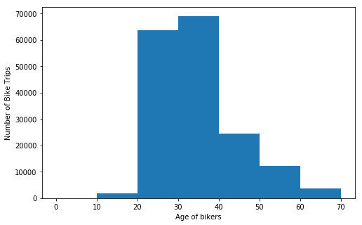

```python
binsize = 10
bins = np.arange(0, df_clean['member_age'].max()+binsize, binsize)

plt.figure(figsize=[8, 5])
plt.hist(data = df_clean, x = 'member_age', bins = bins)
plt.xlabel('Age of bikers')
plt.ylabel('Number of Bike Trips');
plt.show()
```

##### Histogram above shows the age of the bikers, most of the bikers are between the age of 20-40

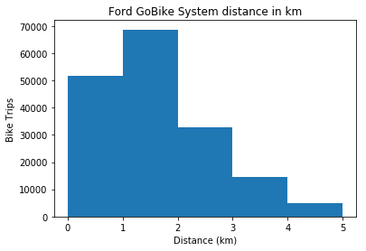

```python
# Distance in traveled in km
bin_edges = np.arange(0, 6, 1)

plt.hist(data = df_clean, x = 'distance_km', bins = bin_edges);

plt.title("Ford GoBike System distance in km")
plt.xlabel('Distance (km)')
plt.ylabel('Bike Trips');
```

##### The charts above showed that most of the riders ride for 1-2 km

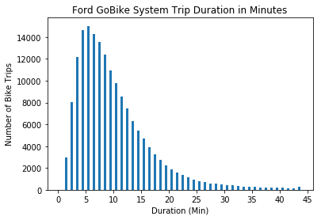

```python
# Duration of the bike rides -in MINUTES
bin_edges = np.arange(0, 45, 1)
ticks = [0, 5, 10, 15, 20, 25, 30,  35, 40, 45]
labels = ['{}'.format(val) for val in ticks]

plt.hist(data = df_clean, x = 'duration_min', bins = bin_edges, rwidth = 0.5);

plt.title("Ford GoBike System Trip Duration in Minutes")
plt.xlabel('Duration (Min)')
plt.xticks(ticks, labels)
plt.ylabel('Number of Bike Trips');
```

##### The chart above showed the duration of bike trips in minutes, most of the riders trips is mostly between 3-10 minutes

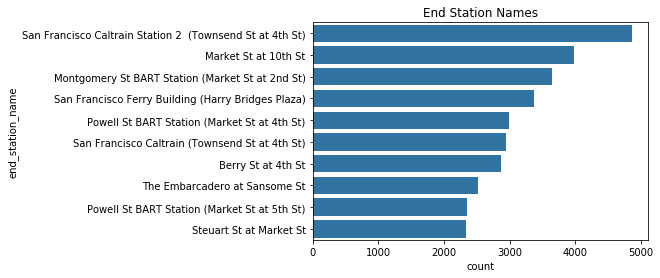

```python
base_color = sb.color_palette()[0]
end_station_name = df['end_station_name'].value_counts().head(10).index
sb.countplot(data = df, y = 'end_station_name', color = base_color, order = end_station_name)
plt.title('End Station Names');
```

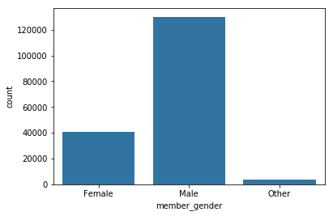

```python
default_color = sb.color_palette()[0]
sb.countplot(data = df_clean, x = 'member_gender', color=default_color)
```

##### From the chart, it can be noted that most of the bikers are male

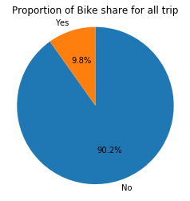

```python
sorted_counts = df_clean['bike_share_for_all_trip'].value_counts()
plt.pie(sorted_counts, labels = sorted_counts.index, startangle = 90, counterclock = False,autopct='%.1f%%');
plt.axis('square');
plt.title('Proportion of Bike share for all trip');
```

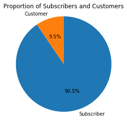

```python
sorted_counts = df_clean['user_type'].value_counts()
plt.pie(sorted_counts, labels = sorted_counts.index, startangle = 90, counterclock = False,autopct='%.1f%%');
plt.axis('square');
plt.title('Proportion of Subscribers and Customers');
```

##### most of the user types are subscribers (90.5%)

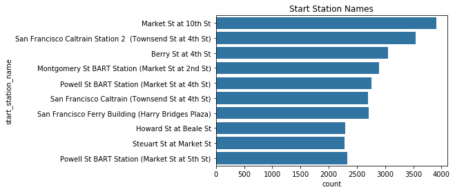

```python
base_color = sb.color_palette()[0]
start_station_name = df_clean['start_station_name'].value_counts().head(10).index
sb.countplot(data = df, y = 'start_station_name', color = base_color, order = start_station_name)
plt.title('Start Station Names');
```

##### Most of the bikers start station is - Market St at 10th St

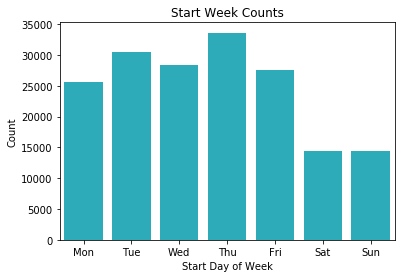

```python
week_days = ['Mon', 'Tue', 'Wed', 'Thu', 'Fri', 'Sat', 'Sun']
week_category = pd.api.types.CategoricalDtype(ordered=True, categories=week_days)
df_clean['start_day'] = df_clean['start_day'].astype(week_category)
base_color = sb.color_palette()[9]
sb.countplot(data=df_clean, x='start_day', color=base_color);
plt.xlabel('Start Day of Week');
plt.ylabel('Count');
plt.title('Start Week Counts');
```

### Of the features you investigated, were there any unusual distributions? Did you perform any operations on the data to tidy, adjust, or change the form of the data? If so, why did you do this?

> Nothing appears to be unusual for a bike-sharing system in a large metropolis. According to the data, the bike-sharing main user base is made up of adults in the average working age range of 20-40 years who utilize the bikes for their everyday trips, and most of the bikers are subscribers only few are customers

## Bivariate Exploration

```
Text(0.5,1,'Gender of Bikers on days of week')
```

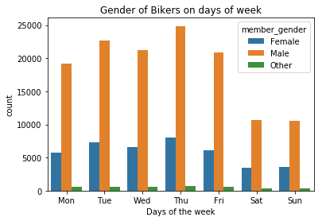

```python
sb.countplot(data = df_clean, x = 'start_day', hue = 'member_gender')
plt.xlabel('')
plt.title('Gender of Bikers on days of week')
```

##### Most of the bikers were male, and there were more trips by all the genders during the weekdays than weekends

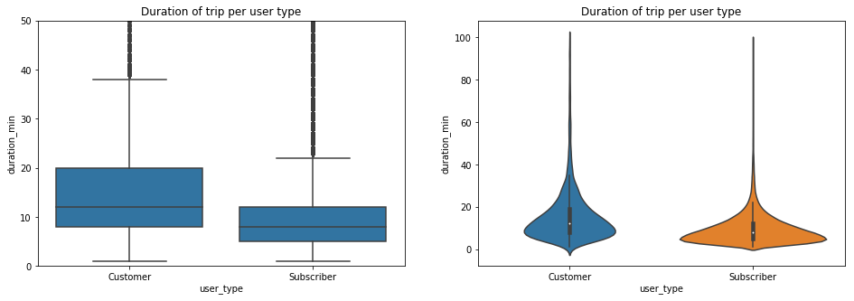

```python
# Customer Usage by Month vs. Subscriber Usage by Month
#plt.figure(figsize = [12, 5])
plt.figure(figsize = [16, 5])
base_color = sb.color_palette()[0]

# left plot: box plot
plt.subplot(1, 2, 1)
ax1 = sb.boxplot(data = df_clean, x = 'user_type', y = 'duration_min', color = base_color)
plt.ylim(0,50)
plt.title('Duration of trip per user type');

# right plot: violinplot;
plt.subplot(1, 2, 2)
sb.violinplot(data=data, x='user_type', y="duration_min", height=5, aspect=2);
plt.title('Duration of trip per user type');
```

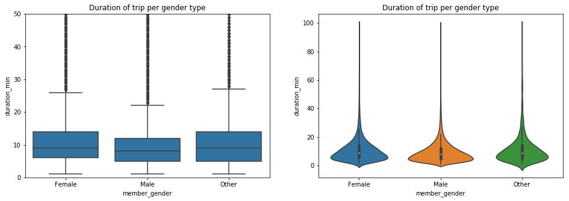

```python
plt.figure(figsize = [16, 5])
base_color = sb.color_palette()[0]

# left plot: box plot
plt.subplot(1, 2, 1)
ax1 = sb.boxplot(data = df_clean, x = 'member_gender', y = 'duration_min', color = base_color)
plt.ylim(0,50)
plt.title('Duration of trip per gender type');

# right plot: violinplot;
plt.subplot(1, 2, 2)
sb.violinplot(data=data, x='member_gender', y="duration_min", height=5, aspect=2);
plt.title('Duration of trip per gender type');
```

#### Interestingly, it appears that there are some relationships between the categorical variables and the numeric variables of interest male gender travled less than other genders as displayed by the plots

[figure not shown]

```python
sb.countplot(data=df_clean, x='start_day', hue='user_type');
plt.xlabel('Day of Week');
plt.ylabel('Count');
plt.title('Relationship between usertype and days of the Week');
```

##### Most of the riders has the highest trips on weekdays and less trip on weekends as depicted from the chart. There are more subscribers than customers across the days of the week

```python
numeric_vars = [ 'distance_km', 'member_age', 'start_station_id', 'end_station_id']
```

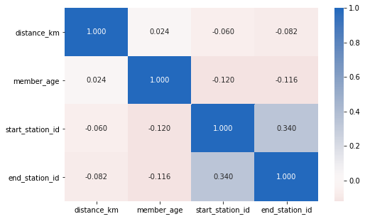

```python
plt.figure(figsize = [8, 5])
sb.heatmap(data[numeric_vars].corr(), annot = True, fmt = '.3f',
           cmap = 'vlag_r', center = 0)
plt.show()
```

### relationships between the other features (not the main feature(s) of interest)?

> There is a difference in the trip duration between customers and subscribers. Customers' trips are usually longer than for subscribers. Subscribers use the system mainly for commute purposes so they prefer quick, short rides to and from work. Another interesting relationship was depicted between the genders, males tends to make more trips than other genders, but then, females happens to travel more time than the males

## Multivariate Exploration

```
Text(0,0.5,'Travel Time (min)')
```

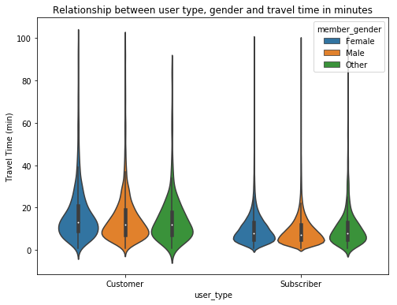

```python
fig = plt.figure(figsize = [8,6])
sb.violinplot(data=data, x='user_type', y="duration_min", hue="member_gender", height=5, aspect=2);
plt.title('Relationship between user type, gender and travel time in minutes')
plt.ylabel('Travel Time (min)')
```

[figure not shown]

```python
plt.suptitle('Hourly Usage during Weekdays for Customers and Subscribers')
#fig, ax = plt.subplots(figsize=(5,5))

plt.figure(figsize = (16,8))
plt.subplot(2, 1, 1)
customers = df_clean.query('user_type == "Customer"')
ct_counts = customers.groupby(['start_day', 'hour']).size()
ct_counts = ct_counts.reset_index(name='count')
ct_counts = ct_counts.pivot(index='start_day', columns='hour', values='count')
sb.heatmap(ct_counts, cmap='YlGnBu');
plt.title('Customer', loc='right');
plt.xlabel('Hour of Day');
plt.ylabel('Day of Week');

plt.subplot(2, 1, 2)
subscribers = df_clean.query('user_type == "Subscriber"')
st_counts = subscribers.groupby(['start_day', 'hour']).size()
st_counts = st_counts.reset_index(name='count')
st_counts = st_counts.pivot(index='start_day', columns='hour', values='count')
sb.heatmap(st_counts, cmap='YlGnBu');
plt.title('Subscriber', loc='right');
plt.xlabel('Hour of Day');
plt.ylabel('Day of Week');
```

### Interesting or surprising interactions between features?

> It was intriguing to observe the significant difference between males and females compared to other groups as well as how the trip time is roughly proportionate to the user base. There are more males biker M, but females spend more time on trips than the other gender. In addition, there seems to be some difference in the use of bike by the customers during the weekends than the subscribers